# Radio Calculation Notebook

What it says on the tin. Used to calculate values concerning radio placement of sector antennas.

## Variables

There are many variables that can be calculated for, and a constant of *Omega 1*.

**Altitude**, (alt) - altitude of the node  
**Target Alt**, (tgt) - altitude of the radio beam at a given distance  
**Top Alt**, (top) - theoretical top of the beam height at a given distance  
**Bottom Alt**, (bot) - theoretical bottom of the beam height at a given distance  
**Omega 1**, (O1) - beam angle of the sector antenna, 8 degrees (vertical); this is a *constant*  
**Omega 2**, (O2) - vertical tilt of the sector itself; if this is >4 degrees the beam will never intersect the ground  
**Distance**, (dist) - horizontal distance from the node to the area needing coverage

## Assumptions

- Line of Sight (**LOS**)
  - Critical; atmospheric refraction isn't enough to overcome the curvature of the Earth
- All of this is theoretical (currently) and highly experimental
  - This is effectively a LOS calculator
  - This doesn't take into account interferance, Fresnel zone intrusions, trasmit power over the distance
- The user is capable of figuring out if given values will work
  - LOS is important but transmit power is critical
  - Flight Example
    - Lt Col Riley flew with a 4200 radio in a T-6; we aimed a 4400-sector at him
      - We could send signals out at ~55 miles
      - We couldn't really hear back from his radio
        - This is because the 4200 with 2dB antennas was insufficient to send back a good signal at that range
        - We also had issues with aiming the antennas properly
- The values of these calculations are not bounded by physics - they are simple geometry problems
  - There is no propagation limitation, there is no distance maximum, there are no viewshed calculations built in
  - The refraction of the atmosphere is not baked in
  - The Earth's curvature is not built in
- This tool is to be used to find (basically) the distances and angles needed, with no limitation
  - If you want a *top* of 57k feet, and a *bot* of 0 feet, the distance is going to be extremely large, and may greatly exceed the distances the radios can actually cover

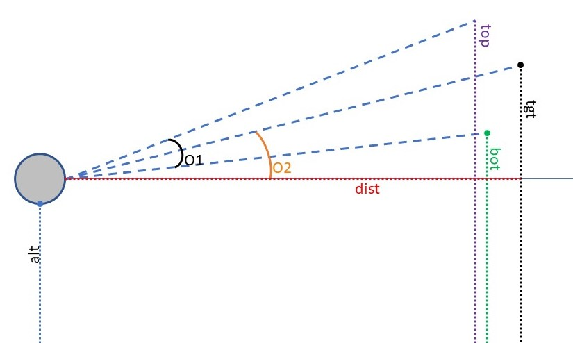

```python
from math import tan
from math import atan
from math import radians
from math import degrees
```

```python
# solve for needed radio Altitude
# alt = top-(dist)tan(O1/2)-(dist)tan(O2)  [top, dist, O1, O2]
#     = bot+(dist)tab(O1/2)-(dist)tan(O2)  [bot, dist, O1, O2]
#     = tgt-(dist)tan(O2)                  [tgt, dist, O2]

def find_alt(top=None, tgt=None, bot=None, dist=None, O1=8, O2=None):
    alt=0
    O1, O2=radians(O1), radians(O2)
    """
    Given specific combos of parameters, returns the needed altitude
        [top, dist, O1, O2] or
        [bot, dist, O1, O2] or
        [tgt, dist, O2]
    """
    if [top, bot, tgt, dist, O1, O2].count(None)==0:
        return "Leave a param blank to solve for."
    if [top, dist, O1, O2].count(None)==0:
        #eq 1
        alt=top-dist*tan(O2+O1/2)
    elif [bot, dist, O1, O2].count(None)==0:
        #eq 2
        alt=bot-dist*tan(O2-O1/2)
    elif [tgt, dist, O2].count(None)==0:
        #eq 3
        alt=tgt-dist*tan(O2)
    else:
        return "Variable combo not recognized"
    return max(alt, 0)
```

```python
# solve for needed Target Alt
# tgt = alt+(dist)tan(O2)                   [alt, dist, O2]
#     = top-(dist)*[tan(O2+O1/2)-tan(O2)]   [top, dist, O1, O2]
#     = bot-(dist)*[tan(O2-O1/2)-tan(O2)]   [bot, dist, O1, O2]

def find_tgt(alt=None, top=None, bot=None, dist=None, O1=8, O2=None):
    tgt=0
    O1, O2=radians(O1), radians(O2)
    """
    Given specific combos of parameters, returns the target altitude
        [alt, dist, O2] or
        [top, dist, O1, O2] or
        [bot, dist, O1, O2]
    """
    if [alt, top, bot, dist, O1, O2].count(None)==0:
        return "Leave a param blank to solve for."
    if [alt, dist, O2].count(None)==0:
        #eq 1
        tgt = alt+dist*tan(O2)
    elif [top, dist, O1, O2].count(None)==0:
        #eq 2
        tgt = top-(dist)*(tan(O2+O1/2)-tan(O2))
    elif [bot, dist, O1, O2].count(None)==0:
        #eq 3
        tgt = bot-(dist)*(tan(O2-O1/2)-tan(O2))
    else:
        return "Variable combo not recognized"
    return max(tgt, 0)
```

```python
## TODO: Add equation based on "tgt"

# solve for expected Top Alt
# top = alt+(dist)*tan(O2+O1/2)                  [alt, dist, O1, O2]
#     = bot-(dist)*[tan(O2-O1/2)-tan(O2+O1/2)]   [bot, dist, O1, O2]

def find_top(alt=None, tgt=None, bot=None, dist=None, O1=8, O2=None):
    top=0
    O1, O2=radians(O1), radians(O2)
    """
    Given specific combos of parameters, returns the target altitude
        [alt, dist, O1, O2] or
        [bot, dist, O1, O2]
    """
    if [alt, bot, dist, O1, O2].count(None)==0:
        return "Leave a param blank to solve for."
    if [alt, dist, O1, O2].count(None)==0:
        #eq 1
        top = alt+(dist)*tan(O2+O1/2)
    elif [bot, dist, O1, O2].count(None)==0:
        #eq 2
        top = bot-(dist)*(tan(O2-O1/2)-tan(O2+O1/2))
    else:
        return "Variable combo not recognized"
    return max(top, 0)
```

```python
## TODO: Add equation based on "tgt"

# solve for expected Bottom Alt
# bot = alt+(dist)*tan(O2-O1/2)                 [alt, dist, O1, O2]
#     = top-(dist)*[tan(O2+O1/2)-tan(O2-O1/2)]  [top, dist, O1, O2]

def find_bot(alt=None, top=None, tgt=None, dist=None, O1=8, O2=None):
    bot=0
    O1, O2=radians(O1), radians(O2)
    """
    Given specific combos of parameters, returns the target altitude
        [alt, dist, O1, O2] or
        [top, dist, O1, O2]
    """
    if [alt, top, tgt, dist, O1, O2].count(None)==0:
        return "Leave a param blank to solve for."
    if [alt, dist, O1, O2].count(None)==0:
        #eq 1
        bot = alt+(dist)*tan(O2-O1/2)
    elif [top, dist, O1, O2].count(None)==0:
        #eq 2
        bot = top-(dist)*(tan(O2+O1/2)-tan(O2-O1/2))
    else:
        return "Variable combo not recognized"
    return max(bot, 0)
```

```python
# solve for needed Omega 2
# O2 = tan^(-1)((tgt-alt)/dist)            [alt, tgt, dist]
#    = tan^(-1)((top-alt)/dist)-O1/2       [alt, top, dist, O1]
#    = tan^(-1)((bot-alt)/dist)+O1/2       [alt, bot, dist, O1]

def find_O2(alt=None, top=None, tgt=None, bot=None, dist=None, O1=8):
    O2=0
    O1=radians(O1)
    """
    Given specific combos of parameters, returns the target altitude
        [alt, tgt, dist] or
        [alt, top, dist, O1] or
        [alt, bot, dist, O1]
    """
    if [alt, tgt, top, bot, dist, O1].count(None)==0:
        return "Leave a param blank to solve for."
    if [tgt, alt, dist].count(None)==0:
        #eq 1
        O2 = atan((tgt-alt)/dist)
    elif [top, alt, dist, O1].count(None)==0:
        #eq 2
        O2 = atan((top-alt)/dist)-O1/2
    elif [bot, alt, dist, O1].count(None)==0:
        #eq 3
        O2 = atan((bot-alt)/dist)+O1/2
    else:
        return "Variable combo not recognized"
    return degrees(O2)
```

```python
# solve for needed Distance
# dist = (bot-alt)/tan(O2-O1/2)   [alt, bot, O1, O2]
#      = (top-alt)/tan(O2-O1/2)   [alt, top, O1, O2]
#      = (tgt-alt)/tan(O2)        [alt, tgt, O2]

def find_dist(alt=None, top=None, tgt=None, bot=None, O1=8, O2=None):
    dist=0
    O1, O2=radians(O1), radians(O2)
    """
    Given specific combos of parameters, returns the needed distance
        [alt, bot, O1, O2] or
        [alt, top, O1, O2] or
        [alt, tgt, O2]
    """
    if [alt, tgt, top, bot, O1, O2].count(None)==0:
        return "Leave a param blank to solve for."
    if [alt, bot, O1, O2].count(None)==0:
        dist = (bot-alt)/tan(O2-O1/2)
    elif [alt, top, O1, O2].count(None)==0:
        dist = (top-alt)/tan(O2+O1/2)
    elif [alt, tgt, O2].count(None)==0:
        dist = (tgt-alt)/tan(O2)
    else:
        return "Variable combo not recognized"
    return dist
```